# Laboratory 2

Simulation, examples and exercises

G. Di Credico

Spring 2020

# Monte Carlo simulation

As we have already seen, *simulation* is a well-known technique designed to approximate a process and to retrieve general results by assuming to observe the process several times. We rely on the so called **Monte Carlo** simulation, a wide class of simulation procedures based on sampling iid values from a process —precisely, from the underlying presumibly true probability distribution of the process— and computing numerical outputs. In what follows, we will consider the behaviour of some sample statistics, such as the mean and the variance, through their sample distribution. The steps of a Monte Carlo simulation are:

- generate $n$ iid values from a process;
- compute a summary for this sample, a statistic;
- repeat the steps above $R$ times and obtain a sample distribution for the statistic.

## Distribution of the sample mean

Suppose three different cases:

- $y_1, \ldots, y_n \sim \mathcal{N}(0,1)$;
- $y_1, \ldots, y_n \sim t_{3}$;
- $y_1, \ldots, y_n \sim \mbox{Unif}(0,1)$.

Which is the distribution of the sample mean $\overline{Y}=\frac{1}{n}\sum_{i=1}^{n}y_{i}$? Before answering, let’s investigate this issue via simulation, with $R=1000$ and $n=30$.

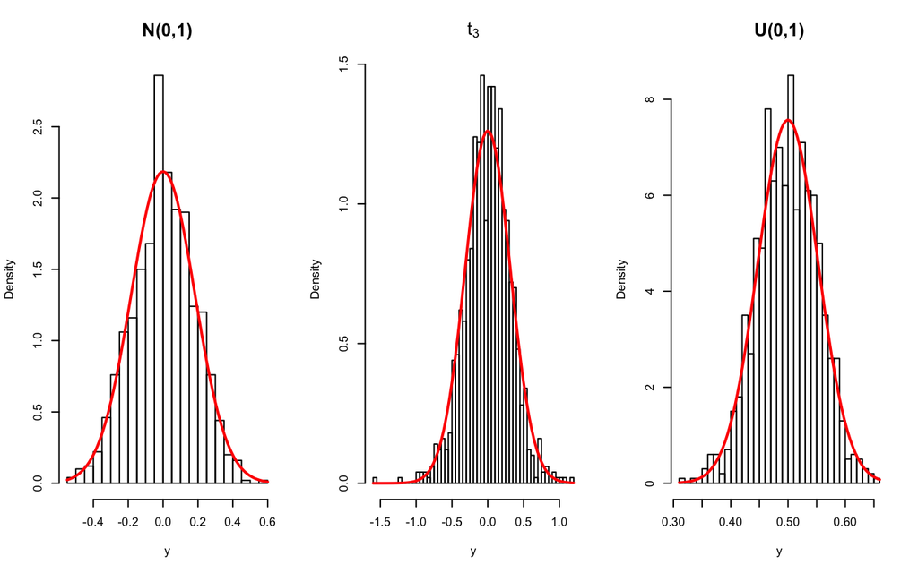

```r
set.seed(123)
R <- 1000
n <- 30
#generate n values R times
samples <- array(0, c(3,R,n))
  for (i in 1:R){
    samples[1, i, ] <- rnorm(n, 0, 1)
    samples[2, i, ] <- rt(n, df = 3)
    samples[3, i, ] <- runif(n, 0, 1)
  }
#compute the sample statistics

samples_stat <- array(0, c(3, 2, R))
  for (j in 1:3){
  #sample mean over R replications
    samples_stat[j, 1, ] <- apply(samples[j, , ], 1 , mean )
  #sample variance over R replications
    samples_stat[j, 2, ] <- apply(samples[j, , ], 1 , var )
  }

#visualize the results
par (mfrow=c(1,3), oma=c(0,0,0,0))
hist(samples_stat[1, 1, ], breaks= 40, probability = TRUE,
xlab="y", main= "N(0,1)", cex.main=1.5)
#overlap the true distribution for the sample mean
curve(dnorm(x, 0, sqrt(1/n)), add = TRUE, col = "red", lwd = 2)

hist(samples_stat[2, 1, ], breaks= 40, probability = TRUE,
xlab="y", main= expression(t[3]), cex.main =1.5)
#overlap the asymptotic distribution for the sample mean
  curve(dnorm(x, 0, sqrt(  (3/((3-2)*n)))), add = TRUE, col = "red", lwd = 2)

hist(samples_stat[3, 1, ], breaks= 40, probability = TRUE,
xlab="y", main=  "U(0,1)", cex.main = 1.5)
#overlap the asymptotic distribution for the sample mean
curve(dnorm(x, 1/2, sqrt(1/(12*n))), add = TRUE, col = "red", lwd = 2)
```

As we already know from the theory, in the Gaussian case the **sample mean** $\overline Y$ for iid values still follows a normal distribution, precisely $\mathcal{N}(\mu, {\sigma^{2}}/{n})$. For other distributions—see the plots above—this result is true only asymptotically, when $n \rightarrow \infty$, due to the CLT theorem. When the sampling does not come from a Normal distribution, we will use the short notation $\overline{Y} \overset{\cdot}{\sim} \mathcal{N}(\mu, {\sigma^{2}}/{n})$.

## Distribution of the sample variance

We know that $s^{2}= \frac{1}{n-1} \sum_{i=1}^{n}(y_{i}-\bar{y})^{2}$ is an unbiased estimator for the variance, and this is exatcly the output provided by $\mathsf{R}$ through the function $\mathsf{var()}$ applied to a sample vector. In the example above, we have already stored the variance. If the assumed true model is normal, we know that the distribution of the sample variance is proportional to a $\chi^{2}$ distribution with $n-1$ degrees of freedom:

$$s^2 \sim \frac{\sigma^{2}}{n-1} \chi^{2}_{n-1}$$

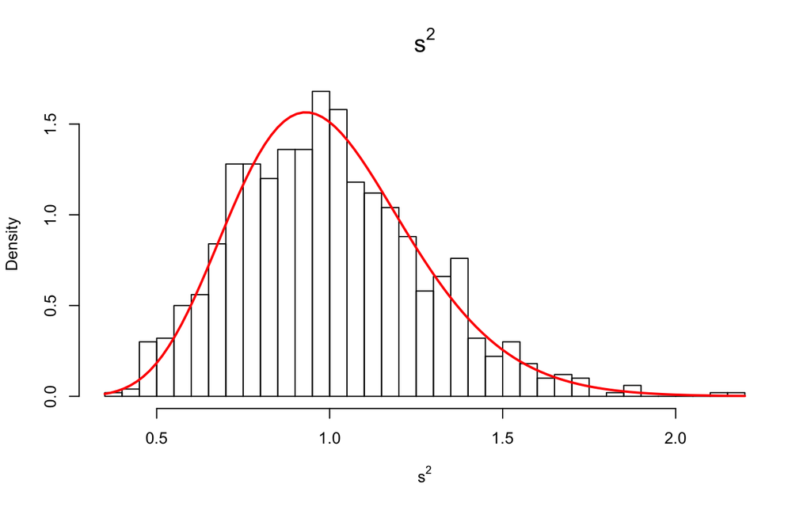

```r
#visualize the results: variance
sigma <- 1
par (mfrow=c(1,1), oma=c(0,0,0,0))
hist(samples_stat[1, 2, ], breaks= 40, probability = TRUE,
xlab=expression(s^2), main= bquote(s^2), cex.main=1.5)
curve(((n-1)/sigma^2) * dchisq(x * ((n-1)/sigma^2), df = n - 1),
add = TRUE, col="red", lwd=2, main="N(0,1)")
```

We could also rely on the biased estimator $s^{2}_{b}= \frac{1}{n}\sum_{i=1}^{n}(y_{i}-\bar{y})^{2}$.

**Exercise 1**

Check the biased nature of $s^{2}_b$ via MC simulation, generating $n = 10$ iid values from a normal distribution. Plot also $s^2$ and comment the difference.

# Basic concepts of estimation

## Point estimation

We will denote with $\hat{{\theta}}$ the point estimator for the parameter ${\theta}$. An estimator is said to be **unbiased** iff

$$E(\widehat{{\theta}})= {\theta}.$$

An estimator is said to be **consistent** if

$$\widehat \theta \overset{P}{\rightarrow} \theta, \ \text{as } n \rightarrow \infty,$$
or, equivalently, if $\text{var}(\widehat \theta) \rightarrow 0, \ \text{as } n \rightarrow \infty$.

There are some properties we would ensure for an estimator: **low variance** and **low bias**. But, there is *tradeoff* between unbiasedness and low variance, so we usually seek to get both (to some extent); ideally we would target a small **Mean Squared Error (MSE)**:

$${\rm MSE}(\widehat\theta) = E\{(\widehat\theta-\theta)^2 \} = \{ E(\widehat\theta)-\theta \}^2 + \text{var}(\widehat\theta)=\text{Squared bias}
+\text{Variance} \, .$$

As we already know from the theory, the sample mean is an excellent estimator for the population mean. But we will consider now other estimators. Consider the well-known case of a normal distribution $\mathcal{N}(\mu, \sigma^{2})$, and the following estimators:

- sample mean: $\widehat \mu_{1}= \bar{y}$;
- median: $\widehat \mu_{2}=\text{Me}(y)$;
- the semi-sum of the maximum and the minimum: $\widehat \mu_{3}=\frac{1}{2}(\max{y}+\min{y})$;
- the trimmed mean $\widehat \mu_{4}= \frac{1}{n-2}\sum_{i=2}^{n-1}y_{(i)}$;

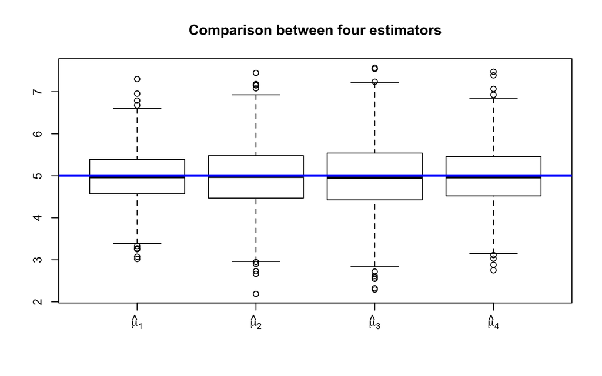

```r
set.seed(4)
# number of replications
R <- 1000
#number of samples for each replication
n <- 10
mu <- 5
sigma <- 2

estimator_1 <- c()
estimator_2 <- c()
estimator_3 <- c()
estimator_4 <- c()
y <- matrix(NA, R,n)

  for (i in 1:R){
    y[i, ] <- rnorm(n, mu, sigma)
    estimator_1[i] <- mean(y[i, ])
    estimator_2[i] <- median(y[i, ])
    estimator_3[i] <- (max(y[i, ])+min(y[i, ]))/2
    estimator_4[i] <- sum(sort(y[i, -c(1,n)]))/(n-2)
  }

par(mfrow=c(1,1), xaxt="n")
boxplot(cbind(estimator_1, estimator_2, estimator_3, estimator_4), main="Comparison between four estimators")
par(xaxt="s")
axis(1, 1:4, c(expression(hat(mu)[1]), expression(hat(mu)[2]), expression(hat(mu)[3]), expression(hat(mu)[4])) )
abline(h=5, lwd=2, col="blue")
```

Now we should compare the estimators above in terms of unbiasedness, efficiency, consistency and robustness. All the four estimators appear unbiased. But what about their efficiency?

```r
estimators <- cbind(estimator_1, estimator_2, estimator_3, estimator_4)
variances <- c()

  for (g in 1:4){
    variances[g] <- var (estimators[,g])
  }

variances
```

```
## [1] 0.3953956 0.5827665 0.7171456 0.5024695
```

The sample mean registers the lowest variance, which is a good approximation for $\sigma^{2}/n= 4/10 =0.4$. Let’s check now whether all the estimators are consistent. For checking this statement, $n=10$ is extremely low and we need to increse it, let’s say $n=200$.

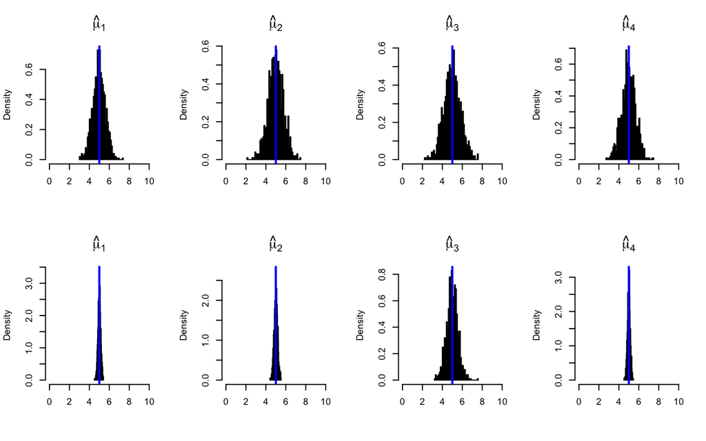

```r
#normal case

estimators_cons <- matrix(NA, R, 4)
n <- 200


  for (i in 1:R){
    y <- rnorm(n, mu, sigma)
    estimators_cons[i , 1] <- mean(y)
    estimators_cons[i , 2] <- median(y)
    estimators_cons[i , 3] <- (max(y)+min(y))/2
    estimators_cons[i , 4] <- sum(sort(y[ -c(1,n)]))/(n-2)
  }


# n =10
par(mfrow=c(2,4))
  for (g in 1:4){
    hist(estimators[,g],  probability = TRUE,
      breaks=40, main=substitute(hat(mu)[g] ,list(g = g)),
      xlab="", xlim=c(0,10), cex.main = 1.5)
      abline(v=mu, col="blue", lwd=2)
  }

# n= 200

  for (g in 1:4){
    hist(estimators_cons[,g],  probability = TRUE,
      breaks=40, main=substitute(hat(mu)[g] ,list(g = g)),
      xlab="", xlim=c(0,10), cex.main = 1.5)
      abline(v=mu, col="blue", lwd=2)
  }
```

In the plot above, the first row displays the four estimators for $n=10$, while the second row displays the same estimators for $n=200$.

## Interval estimation

Giving a point value is in most cases a rude estimate. Rather, we may construct an interval for our parameter, giving an entire set of values to estimate the model parameter. Interval estimation is based upon **pivotal quantities**; in the normal case with $\sigma^{2}$ *known*, the pivotal quantity for $\mu$ is defined as:

$$T(\mu) = \dfrac{\overline{Y}-\mu}{{\dfrac{\sigma}{\sqrt{n}}}} \sim \mathcal{N}(0,1) \, , \hspace{1cm}
\forall \mu \in \mathbb{R}\, , \sigma^2>0.$$
Then, it follows that for $0<\alpha<1$

$$Pr (-z_{1-\alpha/2} \le T(\mu) \le z_{1-\alpha/2} )= 1-\alpha,$$

and a confidence interval of level $1-\alpha$ for $\mu$ is given by:

$$\left(\bar{y}-z_{1-\alpha/2}\frac{\sigma}{\sqrt{n}},\ \bar{y}+z_{1-\alpha/2}\frac{\sigma}{\sqrt{n}} \right),$$
where $-z_{1-\alpha/2}, z_{1-\alpha/2}$ represent the $\alpha/2$ and the $1-\alpha/2$ quantiles of the standard normal distribution respectively. Also for interval estimation, MC simulation is well suited for exploring the procedure:

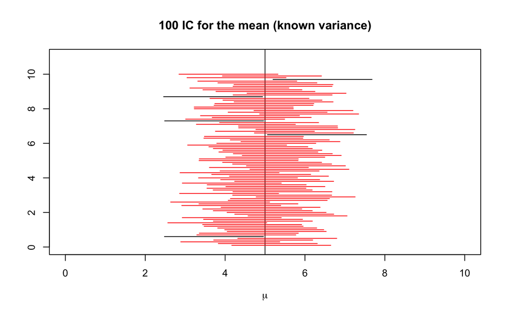

```r
#normal case
set.seed(345)

R <- 100
n <- 10

plot(0,0,xlim=c(0,10),ylim=c(0,11), type="n", xlab=expression(mu), ylab="",
main = paste("100 IC for the mean (known variance)"), cex.main=1.2)
abline(v=mu)
alpha <- 0.05
inf <- vector(mode="numeric", length=R)
sup <- vector(mode="numeric", length=R)
l <- vector(mode="numeric",   length=R)
d <- 0
  for (i in 1:R)
  {
    y <- rnorm(n, mu, sigma)
    inf[i] <- mean(y)-qnorm(1-alpha/2)*sigma/sqrt(n)
    sup[i] <- mean(y)+qnorm(1-alpha/2)*sigma/sqrt(n)
    d <- d + 0.1
    l[i] <- (mu > inf[i] & mu < sup[i])
    lines(seq(inf[i],sup[i],length=100), rep(d, 100), col=(l[i]+1))
  }
```

```r
# compute the coverage
sum(l)
```

```
## [1] 95
```

For the mean of a normal distribution when $\sigma^{2}$ is *unknown*, we have the following result:

$$T(\mu) = \dfrac{\overline{Y}-\mu}{{\dfrac{s}{\sqrt{n}}}} \sim t_{n-1} \, , \hspace{1cm}
\forall \mu \in \mathbb{R}\, , \sigma^2>0$$
Repeat the MC simulation steps to obtain the same plot as the one in the previous case and compute the coverage.

Let’s take an example with real data. The dataset $\mathsf{pair65}$ in the $\mathsf{DAAG}$ package contains the differences in mm between the members of nine pairs of elastic bands. One member of each pair was placed in hot water for four minutes, while the other was left at ambient temperature. After ten minutes, the differences were recorded:

```r
library(kableExtra)
library(DAAG)
options(knitr.table.format = "html")
pair_data_frame <- cbind(pair65, pair65[,1]-pair65[,2])
pair_data_frame <- cbind(c(1:9), pair_data_frame)
dimnames(pair_data_frame)<- list(1:9, c("pair","heated", "ambient", "difference"))

kable(pair_data_frame, "html") %>%
  kable_styling(bootstrap_options = "striped", full_width = F)
```

| pair | heated | ambient | difference |
| --- | --- | --- | --- |
| 1 | 244 | 225 | 19 |
| 2 | 255 | 247 | 8 |
| 3 | 253 | 249 | 4 |
| 4 | 254 | 253 | 1 |
| 5 | 251 | 245 | 6 |
| 6 | 269 | 259 | 10 |
| 7 | 248 | 242 | 6 |
| 8 | 252 | 255 | -3 |
| 9 | 292 | 286 | 6 |

$$\overline d=\overline y_{1}-\overline y_{2} = 6.33.$$
$s=6.10$, and $s/\sqrt{n}=2.03$. The pivotal quantity is then:

$$T(\mu)= \frac{\overline d -\mu}{s / \sqrt{n}}= \frac{\overline d-\mu}{s / \sqrt{9}}=\frac{6.33-\mu}{2.03} \sim t_{8}.$$

We may compute some confidence intervals at $95\%$ or $99\%$.

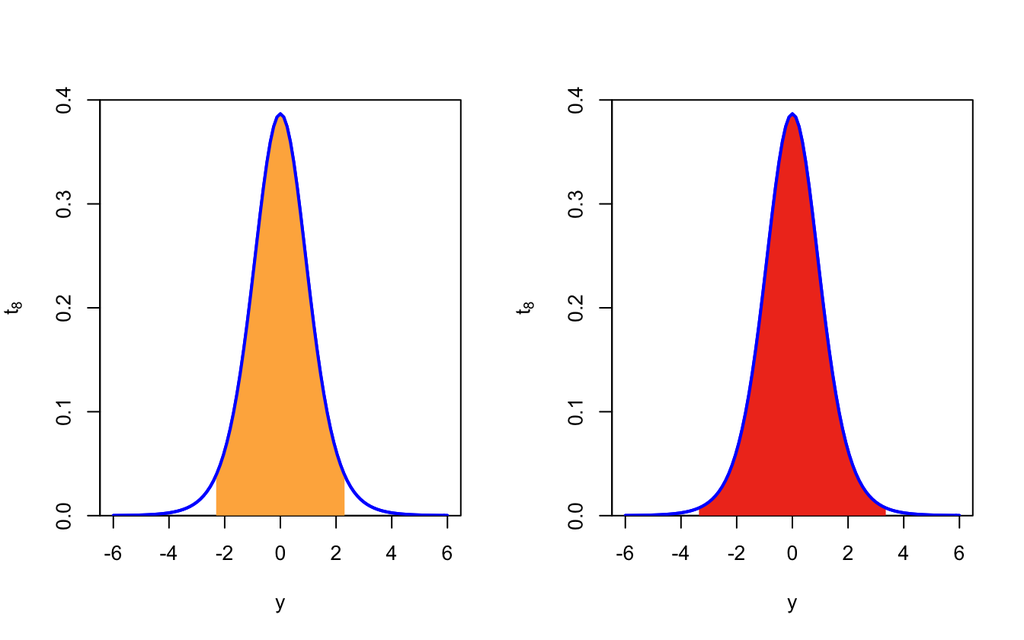

```r
#compute quantiles for student t with n-1 =8 degrees of freedom
 alpha <- 0.05
q_inf_95 <- qt(alpha/2, df=8)
q_sup_95 <- qt(1-alpha/2, df=8)

alpha <- 0.01
q_inf_99 <- qt(alpha/2, df=8)
q_sup_99 <- qt(1-alpha/2, df=8)


#compute the confidence intervals

library(RColorBrewer)
plotclr <- brewer.pal(6,"YlOrRd")
d <- mean(pair_data_frame[,4])
s <- sd(pair_data_frame[,4] )
n <- length(pair_data_frame[,4])

conf_int_95 <- c(d-q_sup_95*s/sqrt(n),d-q_sup_95*s/sqrt(n))
conf_int_99 <- c(d-q_sup_99*s/sqrt(n),d-q_sup_99*s/sqrt(n))

par(mfrow=c(1,2), oma=c(0,0,0,0))

# 95% confidence interval

curve(dt(x,8),xlim=c(-6,6), ylim=c(0,0.4),
  main="", col = "blue", lwd = 2, xlab="y", ylab=expression(t[8]),  yaxs="i")
cord.x <- c(q_inf_95,seq(q_inf_95,q_sup_95,0.01),q_sup_95)
cord.y <- c(0,dt(seq(q_inf_95,q_sup_95,0.01),8),0)
polygon(cord.x,cord.y,col=plotclr[3], border = NA )
curve(dt(x,8),xlim=c(-6,6),main=expression(t[8]), col = "blue", lwd = 2, add = TRUE, yaxs="i")

# 99% confidence interval

curve(dt(x,8),xlim=c(-6,6), ylim=c(0,0.4),
  main="", col = "blue", lwd = 2, xlab="y",  ylab=expression(t[8]),  yaxs="i")
cord.x2 <- c(q_inf_99,seq(q_inf_99,q_sup_99,0.01),q_sup_99)
cord.y2 <- c(0,dt(seq(q_inf_99,q_sup_99,0.01),8),0)
polygon(cord.x2,cord.y2,col=plotclr[5], border = NA )
curve(dt(x,8),xlim=c(-6,6),main=expression(t[8]), col = "blue", lwd = 2, add = TRUE, yaxs="i")
```

# Basic concepts of hypothesis testing

The null hypothesis for the parameter $\theta$ is usually expressed as

$$H_{0}: \theta=\theta_0.$$

Complementary to the choice of $H_0$, it is required to select an alternative hypothesis $H_1$, specifying the values of the parameter which become reasonable when $H_0$ does not hold. Usually $H_1$ may be:

- $H_1: \theta > \theta_0$ or $H_1: \theta < \theta_0$ (**one-sided alternative**);
- $H_1: \theta \ne \theta_0$ (**two-sided alternative**).

## Test for the mean difference

Consider now the number of the 15 most followed accounts on Instagram, expressed in millions, with each total rounded to the nearest million followers, as of March 31, 2018 (Source: *Wikipedia*). Among them, there are 6 musicians and 9 non musicians (called others).

```r
Musicians <- c( "Selena Gomez",  "Ariana Grande", "Beyonce" , "Taylor Swift",  "Justin Bieber", "Nicki Minaj")
Others <- c("Cristiano Ronaldo", "Kim Kardashian",  "Kylie Jenner", "Dwayne Johnson", "Neymar", "Lionel Messi",
  "Kendall Jenner", "Kourtney Kardashian", "Kevin Hart")

n1 <- length(Musicians)
n2 <- length(Others)

Followers_M<- c(135, 118, 113, 107,  98,  86 )
Followers_O <- c(123, 110, 106, 103,  91,  89,  89,  62,  58)
```

| Musicians | Followers_M |
| --- | --- |
| Selena Gomez | 135 |
| Ariana Grande | 118 |
| Beyonce | 113 |
| Taylor Swift | 107 |
| Justin Bieber | 98 |
| Nicki Minaj | 86 |

| Others | Followers_O |
| --- | --- |
| Cristiano Ronaldo | 123 |
| Kim Kardashian | 110 |
| Kylie Jenner | 106 |
| Dwayne Johnson | 103 |
| Neymar | 91 |
| Lionel Messi | 89 |
| Kendall Jenner | 89 |
| Kourtney Kardashian | 62 |
| Kevin Hart | 58 |

We could set up a test with the following aim: do the musicians, in average, have the *same number* of followers than the non-musicians (null hypothesis)? Or, do the musicians have *more* followers? (alternative hypothesis). If we suppose that $X_{i} \sim \mathcal{N}(\mu_{m}, \sigma^{2}_{m}), i=1,\ldots,n_1$ and $Y_{j} \sim \mathcal{N}(\mu_{o}, \sigma^{2}_{o}), j=1,\ldots,n_2$ are **independent normal samples**, where $n_1$ and $n_2$ denote the number of musicians and others, respectively, we aim at comparing their means, $\mu_{m}$ and $\mu_{o}$ through the following one-sided **two-sample test**:

$$\begin{cases}
H_0: \mu_{m}-\mu_{o} = 0 \\
H_1: \mu_{m}-\mu_{o} > 0 \\
\end{cases}$$

Let $\overline X$ denote the sample mean for the musicians and $\overline Y$ the sample mean for the others. After a preliminary $F$-test about the variances of the two groups, we may assume that $\sigma^{2}_{m}=\sigma^{2}_{o}$, and then the test statistic for the test above has the form:

$$T= \frac{\overline X- \overline Y}{s \sqrt{ \frac{1}{n_1}+\frac{1}{n_2}}} \underset{H_{0}}{\sim}t_{n_1+n_2-2},$$
where $n_1+n_2-2= 6+9-2=13$.

```r
t <- t.test(Followers_M, Followers_O, mu = 0, alternative ="greater", var.equal =TRUE)
t
```

```
##
##  Two Sample t-test
##
## data:  Followers_M and Followers_O
## t = 1.6442, df = 13, p-value = 0.06204
## alternative hypothesis: true difference in means is greater than 0
## 95 percent confidence interval:
##  -1.322964       Inf
## sample estimates:
## mean of x mean of y
## 109.50000  92.33333
```

The $p$-value is 0.06204, slightly greater than $\alpha$, when $\alpha=0.05$.

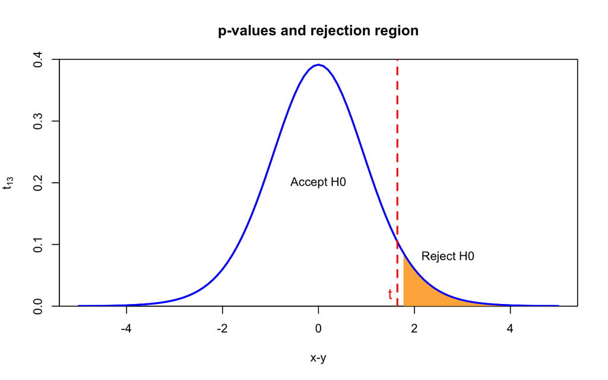

```r
curve(dt(x,13),xlim=c(-5,5), ylim=c(0,0.4),
  main="p-values and rejection region", col = "blue", lwd = 2, xlab="x-y",  ylab=expression(t[13]),  yaxs="i")
cord.x <- c(qt(0.95,13),seq(qt(0.95,13), 5, 0.01), 5)
cord.y <- c(0,dt(seq(qt(0.95,13), 5, 0.01),13),0)
polygon(cord.x,cord.y,col=plotclr[3], border = NA )
curve(dt(x,13),xlim=c(-5,5),main=expression(t[13]), col = "blue", lwd = 2, add = TRUE, yaxs="i")
abline(v =t$statistic, lty=2, lwd=2, col="red")
text (0,0.2, paste("Accept", expression(H0)))
text (2.7,0.08, paste("Reject", expression(H0)))
text(as.double(t$statistic)-0.15, 0.02, "t", col="red", cex=1.2)
```

## Pearson’s chi-squared test

This is a class of statistical tests applied to sets of categorical data to evaluate whether any observed difference between the sets arose by chance. It is suitable for unpaired data from large samples. Pearson’s chi-squared test is used to assess three types of comparison: **goodness of fit** (establishes whether an observed frequency distribution differs from a theoretical distribution), **homogeneity**, and **independence**.

- **Goodness of fit: Darts challenge against one friend**

Suppose that $n$ observations $y_{1},\ldots,y_{n}$ are divided among $K$ cells. The following test statistic is then defined:

$$X^{2}= \sum_{k=1}^{K}\frac{ (O_{k}-E_{k})^{2}}{E_{k}} \underset{H_{0}}{\sim} \chi^{2}_{K-1},$$

where $O_{k}$ are the observed frequencies for cell $k$, $E_{k}$ the expected frequencies for cell $k$ under $H_{0}$. But what is $H_{0}$ here?

For illustration pruposes, suppose you are playing darts against another friend.

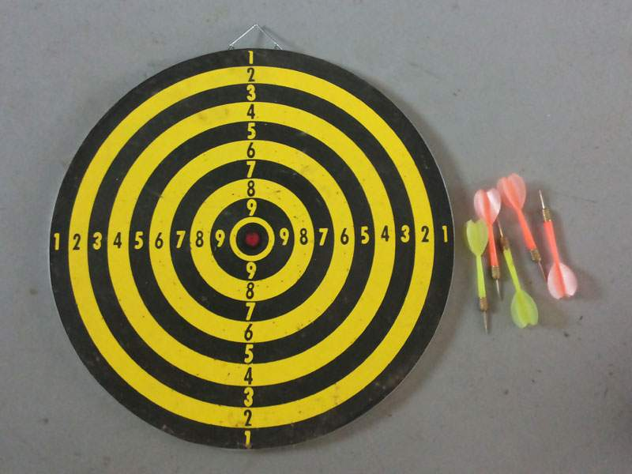

**Darts target**

You suspect that your friend is not a great darts players, and that his shots along the game will hit the lowest points with great probability and the highest point with low probability. Translated in probability terms, you divide the darts target into $K=4$ zones and you assign the following hitting probabilities:

-*Zone 1* (from 1 to 3 points): $p_{1}= 7/16$;

-*Zone 2* (from 4 to 6 points); $p_{2}=5/16$;

-*Zone 3* (from 7 to 9 points); $p_{3}= 3/16$;

-*Zone 4* (the highest points in the middle of the target, say 10, 25, 50 points): $p_{4}= 1/16$;

Your null hypothesis is that, *due to a moderate control on his darts skills*, he has decreasing probabilities to hit the best zones:

$$H_{0}: p_{1}= 7/16;\ p_{2}=5/16;\ p_{3}= 3/16;\ p_{4}= 1/16.$$

Any significative deviation from the above probability distribution, would cause the rejection of your null hypothesis. For checking your assumption, you count the first $n=50$ attempts $y_{1},\ldots,y_{50}$ of your opponent, and you will code $y_{i}=k$, if the $i$-th shot hits the $k$-th zone.

```r
set.seed(101)
n <- 50
K <- 4
# generate the values
y <- sample( 1:K, n, replace=TRUE, prob =c( 7/16, 5/16, 3/16, 1/16))
observed <- table(y)
expected <- c( n*(7/16), n*(5/16), n*(3/16), n*(1/16))
x2 <- sum( (observed-expected)^(2)/expected)
#manually compute the p-value
pchisq(x2, df =K-1, lower.tail =FALSE )
```

```
## [1] 0.551489
```

```r
#same result with the chisq.test function
chisq.test( observed, p = c( 7/16, 5/16, 3/16, 1/16)   )
```

```
##
##  Chi-squared test for given probabilities
##
## data:  observed
## X-squared = 2.1021, df = 3, p-value = 0.5515
```

Yes, your assumption may be accepted, your friend is hitting the target according to your probabilities… but he wants to play again, and performing another challenge. Before starting, he requires to drink an energetic drink. You are ready to count his next 50 attempts. Does the drink improve the performance?

```r
y2 <- sample( 1:K, n, replace=TRUE, prob=c(5/16, 3/16, 6/16, 2/16))
new_observed <- table(y2)
#new test after the energetic drink
chisq.test( new_observed, p = c( 7/16, 5/16, 3/16, 1/16)  )
```

```
##
##  Chi-squared test for given probabilities
##
## data:  new_observed
## X-squared = 16.328, df = 3, p-value = 0.0009711
```

Your friend improved his performance! His new shots do not follow your assumed ditribution. Apparently, the energetic drink was strongly required.

```r
table(y)
```

```
## y
##  1  2  3  4
## 24 14 11  1
```

```r
table(y2)
```

```
## y2
##  1  2  3  4
## 13 13 16  8
```

- **Homogeneity: Darts with more friends**

Suppose now that other five friends join you and the other guy, for a total of $M=6$ friends. Do all of your friends share the same probabilities, with the above probabilites to hit the four zones? We have now this test statistic:

$$X^{2}= \sum_{k=1}^{K} \sum_{m=1}^{M} \frac{(O_{k,m}-E_{k,m})^2}{E_{k,m}} \underset{H_{0}}{\sim} \chi^{2}_{(K-1)(M-1)}$$
For each of them, you count the first 50 shots.

**Exercise 2**

What happens if a great player decides to join you, now? Try to simulate the data and perform the test again.

**Exercise 3**

Sometimes it could be useful to assess the degree of association, or correlation, between paired samples, using the Pearson, the Kendall’s $\tau$ or the Spearman’s $\rho$ correlation coefficient. Regardless of the adopted cofficient, the null hypothesis for a given correlation coefficent $\rho$ is:

$$H_{0}: \rho=0.$$

The test statistic is then defined as

$$T= r\sqrt{\frac{n-2}{1-r^{2}}} \underset{H_{0}}{\sim} t_{n-2},$$

where $r=Corr(X,Y)$ is the Pearson correlation coefficient. Suppose to have two samples of the same length $x_{1},\ldots,x_{n}, y_{1}, \ldots, y_{n}$, and to measure the association between them. Once we compute the test statistic $t_{obs}$, we may then compute the $p$-value (here we are evaluating a two sided test) as:

$$p = 2Pr_{H_{0}}( T \ge |t_{obs}| ).$$

Consider now some of the most followed Instagram accounts in 2018: for each of the owners, we report also the number of Twitter followers (in milions). Are the Instagram and Twitter account somehow associated? Perform a correlation test, compute the $p$-value and give an answer. Here is the dataframe.

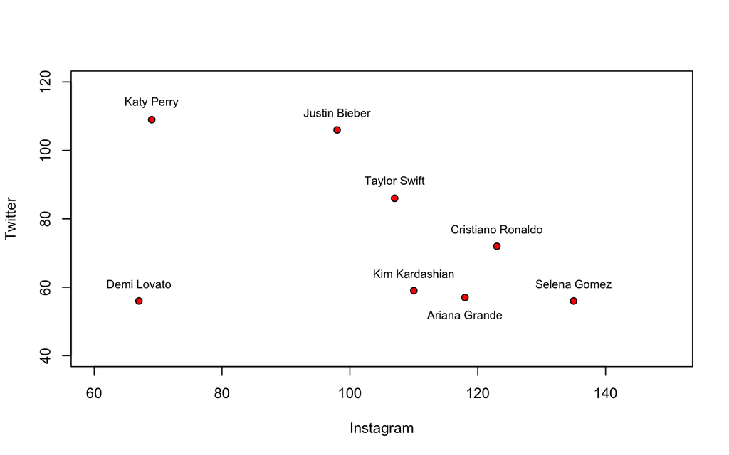

| Owners | Instagram | Twitter |
| --- | --- | --- |
| Katy Perry | 69 | 109 |
| Justin Bieber | 98 | 106 |
| Taylor Swift | 107 | 86 |
| Cristiano Ronaldo | 123 | 72 |
| Kim Kardashian | 110 | 59 |
| Ariana Grande | 118 | 57 |
| Selena Gomez | 135 | 56 |
| Demi Lovato | 67 | 56 |

```r
      Owners <- c( "Katy Perry", "Justin Bieber", "Taylor Swift", "Cristiano Ronaldo",
                   "Kim Kardashian", "Ariana Grande", "Selena Gomez", "Demi Lovato")
      Instagram <- c( 69, 98,107, 123, 110, 118, 135, 67)
      Twitter <- c( 109, 106, 86, 72, 59, 57, 56, 56)
      plot( Instagram, Twitter, pch=21, bg=2, xlim=c(60, 150), ylim=c(40, 120) )
      text( Instagram[-6], Twitter[-6]+5, Owners[-6], cex=0.8 )
      text( Instagram[6], Twitter[6]-5, Owners[6], cex=0.8 )
```

# Weibull model

Let $y=(y_{1},\ldots, y_{n})$ a sample of iid values from a Weibull distribution, $Y \sim \mbox{We}(\gamma, \beta)$, with parameter $\theta=(\gamma, \beta)$ and density function:

$$f (y; \gamma, \beta)= \frac{\gamma}{\beta}\left(\frac{y}{\beta}\right)^{\gamma-1}e^{-(y/\beta)^{\gamma}}, \ \ \ y, \gamma, \beta >0,$$
where $\gamma$ is the *shape* parameter and $\beta$ is the *scale* parameter. Then, the likelihood is defined as:

We may write the log-likelihood function in $\mathsf{R}$:

```r
log_lik_weibull <- function( data, param){
  -sum(dweibull(data, shape = param[1], scale = param[2], log = TRUE))
}
```

## Plotting the log-likelihood

Suppose now to observe $n = 15$ failure times (expressed in days) of a sample of light bulbs: we assume $y_{1}, \ldots, y_{15} \sim \mbox{We}(\gamma, \beta)$, with $\gamma$ and $\beta$ unknown. We need to estimate them via maximum likelihood estimation. Preliminarily, we could inspect the log-likelihood function through **contour** plots.

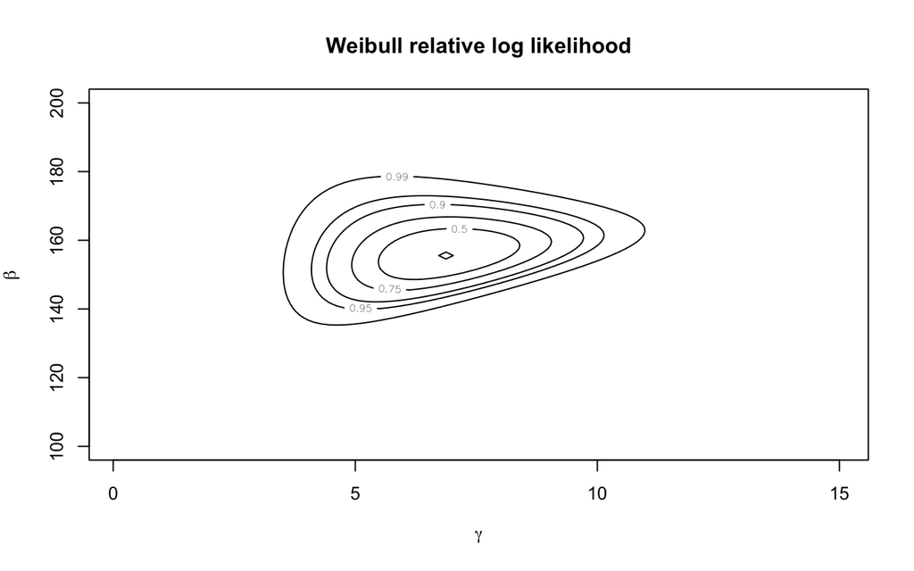

```r
y <- c(155.9, 200.2, 143.8, 150.1,152.1, 142.2, 147, 146, 146,
 170.3, 148, 140, 118, 144, 97)
n <- length(y)

 #define parameters grid
 gamma <- seq(0.1, 15, length=100)
 beta <- seq(100,200, length=100)
 parvalues <- expand.grid(gamma,beta)
 llikvalues <- apply(parvalues, 1, log_lik_weibull, data=y)
 llikvalues <- matrix(-llikvalues, nrow=length(gamma), ncol=length(beta),
 byrow=F)
 conf.levels <- c(0,0.5,0.75,0.9,0.95,0.99)

 #contour plot
 contour(gamma, beta, llikvalues-max(llikvalues),
 levels=-qchisq(conf.levels, 2)/2,
 xlab=expression(gamma),
 labels=as.character(conf.levels),
 ylab=expression(beta))
 title('Weibull relative log likelihood')
```

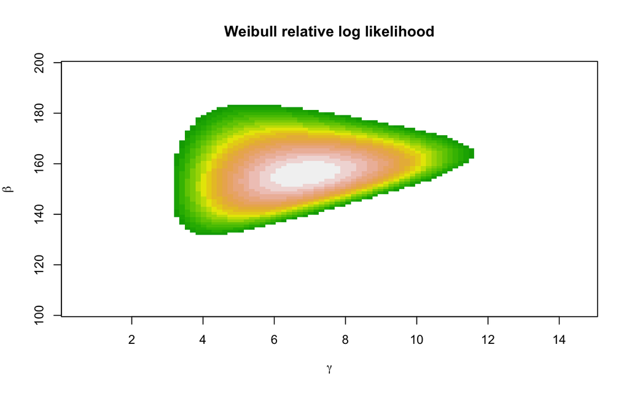

```r
 #image
 image(gamma,beta,llikvalues-max(llikvalues),zlim=c(-6,0),
 col=terrain.colors(20),xlab=expression(gamma),
 ylab=expression(beta))
 title('Weibull relative log likelihood')
```

## Parameter estimates

We may compute the maximum likelihood estimates $\hat{\gamma}, \hat{\beta}$ by equating at zero the log-likelihood derivatives:

$$\begin{align*}
\frac{\partial}{\partial \gamma}l(\gamma, \beta; y)= & \frac{n}{\gamma}-n \log(\beta)+ \sum_{i=1}^{n}\log(y_{i})-\sum_{i=1}^{n}(y_{i}/\beta)^{\gamma}\log( y_{i}/\beta) = 0 \\
\frac{\partial}{\partial \beta}l(\gamma, \beta; y)= & -\frac{n}{\beta} \gamma + \frac{\gamma} {\beta^{\gamma+1}} \sum_{i=1}^{n} y_{i}^{\gamma} = 0
\end{align*}$$

Solving the second equation we get the constrained estimate $\beta_{\gamma}= (\sum_{i=1}^{n} y^{\gamma}_{i}/n)^{1/\gamma}$. Substituting this in the first equation, we get

$$\frac{n}{\gamma}+\sum_{i=1}^{n} \log (y_{i})-n \frac{\sum_{i} y^{\gamma}_{i}\log(y_{i})}{\sum_{i} y^{\gamma}_{i}} =0$$

The last equation needs to be solved numerically.

```r
gammahat<-uniroot(function(x) n/x+sum(log(y))-n*
 sum(y^x*log(y))/sum(y^x),
 c(1e-5,15))$root
 betahat<- mean(y^gammahat)^(1/gammahat)
 weib.y.mle<-c(gammahat,betahat)
 #first element is the MLE for the shape gamma, second element the MLE for the scale beta
 weib.y.mle
```

```
## [1]   6.886215 155.948671
```

Of course, we are interested in assessing the variability and the consistency of our MLE estimators. Let $\theta=(\gamma, \beta)$ denote the bidimensional parameter vector. At this purpose, we may compute the **observed information** matrix

$$J(\theta; y)=- \frac{\partial^{2} l( \theta;y)}{ \partial \theta \partial \theta^{T}}.$$
Taking its inverse, evaluated in $(\hat{\gamma}, \hat{\beta})$, we obtain an estimate for the variance of our estimators. In what follow, we assume to have compute these quantities.

```r
 #observed information matrix
 jhat<-matrix(NA,nrow=2,ncol=2)
 jhat[1,1]<-n/gammahat^2+sum((y/betahat)^gammahat*
 (log(y/betahat))^2)
 jhat[1,2]<-jhat[2,1]<- n/betahat-sum(y^gammahat/betahat^(gammahat+1)*
 (gammahat*log(y/betahat)+1))
 jhat[2,2]<- -n*gammahat/betahat^2+gammahat*(gammahat+1)/
 betahat^(gammahat+2)*sum(y^gammahat)
 solve(jhat)
```

```
##          [,1]      [,2]
## [1,] 1.543250  2.550504
## [2,] 2.550504 38.406106
```

```r
 #se of the mle
 mle.se<-sqrt(diag(solve(jhat)))
 mle.se
```

```
## [1] 1.242276 6.197266
```

**Exercise 4**

Compute analitically $J(\gamma, \gamma; y), J(\gamma, \beta; y), J(\beta, \beta; y)$.

**Exercise 5**

Produce the contour plot for the **quadratic approximation** of the log-likelihood, based on the Taylor series:

$$l(\theta)-l(\hat{\theta}) \approx -\frac{1}{2} (\theta-\hat{\theta})^{T}J(\hat{\theta})(\theta-\hat{\theta}).$$